[figure not shown]

# Functions in Python

[Ahmed Moustafa](https://github.com/ahmedmoustafa)

# Functions

- Functions are **reusable** blocks of code that perform a specific task
- They can take input parameters and return output values
- Functions are essential in modular programming, as they help organize code and make it more readable

# Defining a Function

- To define a function in Python, use the keyword `def` followed by the function name and input parameters in parentheses
- The function body is **indented** below the header line
- Use the keyword `return` to specify the output value(s) of the function

```python
def add_numbers(x, y):
    result = x + y
    return result
```

# Calling a Function

To call a function, use its name followed by input values in parentheses The function returns the output value(s), which can be stored in a variable or used directly

```python
sum = add_numbers(2, 3)
print(sum)
```

```
5
```

# Default Parameter Values

- Functions can have default values for input parameters, which are used when no value is provided
- Default values are specified in the function header

```python
def greet(name, greeting = "Hello"):
    print(greeting + ", " + name)

greet("Alice")
```

```
Hello, Alice
```

```python
greet("Bob", "Hi")
```

```
Hi, Bob
```

# Variable-Length Arguments

- Variable-length arguments allow a function to accept any number of input arguments
- They are useful when the number of input arguments is unknown or can vary

```python
def add_numbers(*args):
    result = 0
    for num in args:
        result += num
    return result

add_numbers
```

```
<function __main__.add_numbers(*args)>
```

```python
add_numbers(1, 2, 3)
```

```
6
```

```python
add_numbers(1, 2, 3, 4, 5)
```

```
15
```

# Function Annotation

```python
def add_numbers(*args):

    """
    Computes the sum of n numbers

    Parameters:
    args: A tuple of numbers

    Returns:
    int: The sum
    """

    result = 0
    for num in args:
        result += num
    return result

help(add_numbers)
```

```
Help on function add_numbers in module __main__:

add_numbers(*args)
    Computes the sum of n numbers

    Parameters:
    args: A tuple of numbers

    Returns:
    int: The sum
```

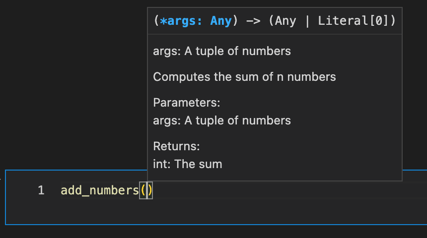

# Lambda Functions

- Lambda functions are **anonymous** functions that can be defined inline and used immediately
- They are useful for *simple* tasks that don't require a named function
- Lambda functions can only have **one** expression

```python
double = lambda x: x * 2
print(double(3))
```

```
6
```

# Recursion

- Recursion is a technique where a function calls itself
- It is useful for solving problems that can be broken down into smaller subproblems

```python
def factorial(n):
    if n == 0:
        return 1
    else:
        return n * factorial(n-1)

print(factorial(5))
```

```
120
```

# Global vs Local Variables

- Global variables are defined outside of any function and can be accessed from anywhere in the program
- Local variables are defined inside a function and can only be accessed within that function

```python
global_var = 10

def my_func():
    local_var = 20
    print(global_var)
    print(local_var)

my_func()
```

```
10
20
```

```python
print(global_var)
```

```
10
```

```python
print(local_var)
```

```
---------------------------------------------------------------------------
NameError                                 Traceback (most recent call last)
Cell In[15], line 1
----> 1 print(local_var)

NameError: name 'local_var' is not defined
```

# Error Handling

- Error handling is the process of detecting and responding to errors in a program
- Python has a try-except block for handling exceptions that might occur in a function

```python
def divide(x, y):
    try:
        result = x / y
    except ZeroDivisionError:
        print("Error: division by zero")
    else:
        return result

print(divide(10, 5))
```

```
2.0
```

```python
print(divide(10, 0))
```

```
Error: division by zero
None
```

# Conclusion

- Functions are a fundamental concept in Python programming
- They help to modularize code, making it more organized and easier to maintain
- There are many types of functions and techniques for working with them
- Understanding these concepts can help to write more efficient, flexible, and readable code